# Introduction to the spca package

Giovanni Maria Merola

2026-09-23

## Package spca

This package contains functions to compute, visualize and compare Least Squares Sparse Principal Components Analysis (LS-SPCA). Differently from other *conventional* SPCA methods, LS-SPCA provides a close approximation to the PCs, thus something like PCA with sparse weights.

An efficient `C++` backend makes the fitting functions fast and memory efficient. Careful input validation and error handling prevents crashes and provides useful error and warning messages.

Methodological details, references and full presentation can be found in the *spca_extended* vignette.

## Installation

You can install the stable release from CRAN

```r
install.packages("spca")
```

or the development version from GitHub

```r
remotes::install_github("merolagio/spca")
```

## Usage

The main function *spca()* computes the sparse weights and various statistics, such as the variance explained by each sparse component (sPC). print, summary and plot methods are available. PCA solutions stored as an `*spca*` object can be obtained with the function *pca()*.

### Load data

The `holzinger` dataset is the small classic Holzinger-Swineford dataset with 145 cases on 12 variables grouped in 4 scales.

```r
library(spca)
data(holzinger)
dim(holzinger)
```

```
#> [1] 145  12
```

```r
holzinger_scales
```

```
#>  [1] SPL SPL SPL VBL VBL VBL SPD SPD SPD MTH MTH MTH
#> Levels: SPL VBL SPD MTH
```

### Preliminary PCA

```
#>         PC1   PC2   PC3   PC4   PC5   PC6   PC7   PC8   PC9  PC10
#> Vexp  40.2% 13.7% 10.6%  6.4%  5.6%  5.1%  4.3%  3.9%  3.2%  2.6%
#> Cvexp 40.2% 53.9% 64.5% 70.9% 76.5% 81.6% 85.9% 89.8% 93.0% 95.6%
#> Card     12    12    12    12    12    12    12    12    12    12
```

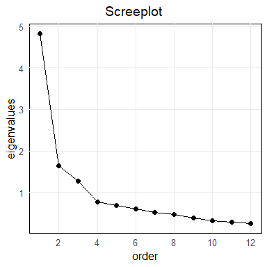

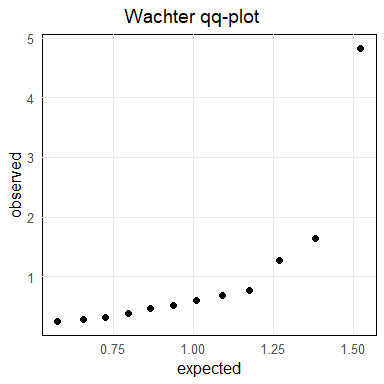

```r
ho_pca = pca(holzinger, screeplot =  TRUE, qq_plot = TRUE)
summary(ho_pca, cols = 10)
```

The screeplot would call for four components while the qqplot indicates three. We can settle for 4 components, acknowledging that the fourth PC may be explaining mainly noise.

### Compute the sparse weights

See the `spca` help for details on these and more parameters.

**The following command** computes four sPCs with default settings: `alpha = 0.95`, `var_selection = forward`, `method = "c"` that selects the `cSPCA` method. Hence, we expect each sPC to yield at least 95% cumulative VEXP, allowing some very mild correlation between sPCs.

```r
ho_spca = spca(holzinger, n_comps = 4)
```

### Inspect spca results

Methods are `print`, `plot` (several options available) and `summary`. By defaut, plot and print show the percentage `contributions`, that is the weights scaled to have sum of their absolute values equal to 1.

```r
ho_spca # print
```

```
#> Percentage contributions
#>             sPC1   sPC2   sPC3   sPC4
#> visual     11.9%                43.9%
#> cubes                    31.4% -21.3%
#> flags      14.2%         23.0%
#> paragraph        -21.6%
#> sentence   19.6%        -29.7%
#> wordm            -22.3%
#> addition   12.2%  27.5% -15.9% -10.6%
#> counting          28.6%
#> straight   12.3%
#> deduct     13.7%               -24.3%
#> series     16.1%
#>            -----  -----  -----  -----
#> Cvexp      38.6%  51.5%  61.4%  67.5%
#>
```

```r
summary(ho_spca, cor_with_pc = TRUE)
```

```
#>         sPC1  sPC2  sPC3  sPC4
#> Vexp   38.6% 12.9%  9.9%  6.1%
#> Cvexp  38.6% 51.5% 61.4% 67.5%
#> Rvexp  96.0% 94.5% 93.5% 95.3%
#> Rcvexp 96.0% 95.6% 95.3% 95.3%
#> Card       7     4     4     4
#> r      0.978 0.946 0.925 0.762
```

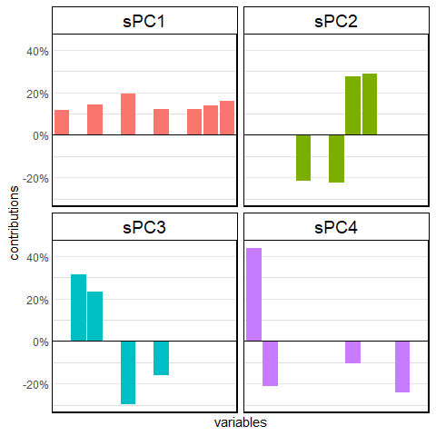

```r
plot(ho_spca, plot_type = "b")
```

```r
#sPCs correlation
show_correlations(ho_spca)
```

```
#>         sPC1  sPC2  sPC3  sPC4
#> sPC1    1.00 -0.01 -0.03 -0.02
#> sPC2   -0.01  1.00 -0.08 -0.10
#> sPC3   -0.03 -0.08  1.00 -0.06
#> sPC4   -0.02 -0.10 -0.06  1.00
#>        ----- ----- ----- -----
#> sPC-PC  0.98  0.95  0.92  0.76
```

The sparse weights can be compared to the full PCA weights with `compare_spca`

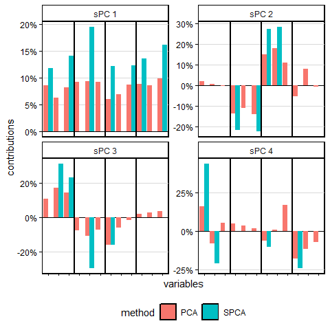

```
#>        C1.M1  C1.M2  C2.M1  C2.M2  C3.M1  C3.M2  C4.M1  C4.M2
#> Vexp    40.2%  38.6%  13.7%  12.9%  10.6%   9.9%   6.4%   6.1%
#> Cvexp   40.2%  38.6%  53.9%  51.5%  64.5%  61.4%  70.9%  67.5%
#> Rvexp  100.0%  96.0% 100.0%  94.5% 100.0%  93.5% 100.0%  95.3%
#> Rcvexp 100.0%  96.0% 100.0%  95.6% 100.0%  95.3% 100.0%  95.3%
#> Card       12      7     12      4     12      4     12      4
#> abs_r    1.00   0.98   1.00   0.95   1.00   0.92   1.00   0.76
```

```r
compare_spca(list(ho_pca, ho_spca), variable_groups = holzinger_scales,
             x_axis_var_names = FALSE,  methods_names = c("PCA", "SPCA")
             )
```

The `variable_groups = group_factor` adds lines separating variable groups. Adding `print_weights = TRUE` would show the contributions side by side.

**Other plot types are available:**

Circular:

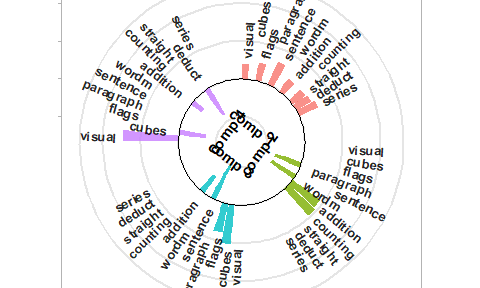

```r
plot(ho_spca, plot_type = "c",     # "c" for "circular"
     controls = list(variable_names = "auto"))
```

Heatmap:

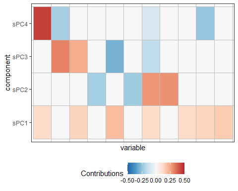

```r
plot(ho_spca, plot_type = "h", controls = list(legend_position = "b")) # "h" is enough to call "heatmap" type and "b" to indicate "bottom".
```

## Variable groups

The variables in the `holzinger` dataset belong to four different scales, recorded in the factor `holzinger_scales`. These can be differentiated in the barplot

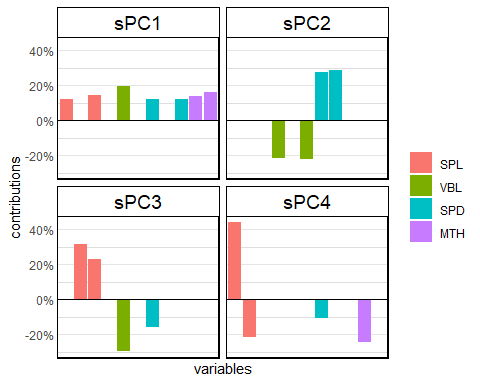

```r
plot(ho_spca, plot_type = "bars", variable_groups = holzinger_scales, controls = list(legend_position = "right"))
```

```r
aggregate_by_group(ho_spca, variable_groups = holzinger_scales)
```

```
#>      sPC1   sPC2   sPC3   sPC4
#> SPL 26.0%         54.4%  22.6%
#> VBL 19.6% -43.9% -29.7%
#> SPD 24.6%  56.1% -15.9% -10.6%
#> MTH 29.8%               -24.3%
```

## Comparison of two or more spca solutions

Compare the *CSPCA* solutions with *alpha = 0.95* those with *alpha = 0.90*.

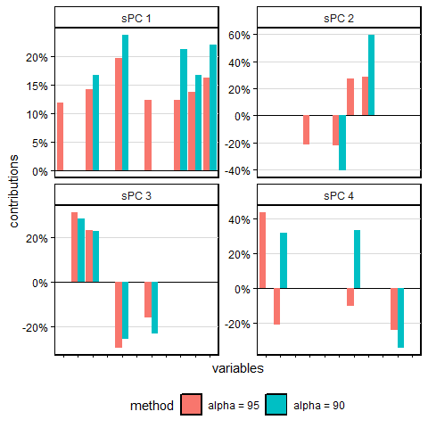

```
#>        C1.M1 C1.M2 C2.M1 C2.M2 C3.M1 C3.M2 C4.M1 C4.M2
#> Vexp   38.6% 37.3% 12.9% 11.2%  9.9%  9.9%  6.1%  6.3%
#> Cvexp  38.6% 37.3% 51.5% 48.5% 61.4% 58.4% 67.5% 64.7%
#> Rvexp  96.0% 92.8% 94.5% 81.9% 93.5% 93.4% 95.3% 97.8%
#> Rcvexp 96.0% 92.8% 95.6% 90.0% 95.3% 90.6% 95.3% 91.2%
#> Card       7     5     4     2     4     4     4     3
#> abs_r   0.98  0.96  0.95  0.87  0.92  0.94  0.76  0.08
```

```r
ho_spca90 = spca(holzinger, n_comps = 4, alpha = 0.9)

compare_spca(obj_list = list(ho_spca, ho_spca90),
             methods_names = c("alpha = 95", "alpha = 90"))
```

## Practical recommendations

The default settings provide a practical starting point for most analyses. Forward selection is recommended for routine use; stepwise and intensive selection are more suitable for smaller problems, while backward elimination can be expensive. The power method may be inaccurate, especially for higher order components, and is mainly useful for large matrices.

| Setting | Small | Medium | Large |
| --- | --- | --- | --- |
| Stepwise selection | Consider | Consider | Avoid |
| Intensive selection | Consider | Use cautiously | Avoid |
| Backward elimination | Use cautiously | Avoid | Avoid |
| `objective = "cvexp"` | Consider | Consider | Use cautiously |
| Power method | Little expected gain | Little expected gain | Consider |